# Weather Modeling

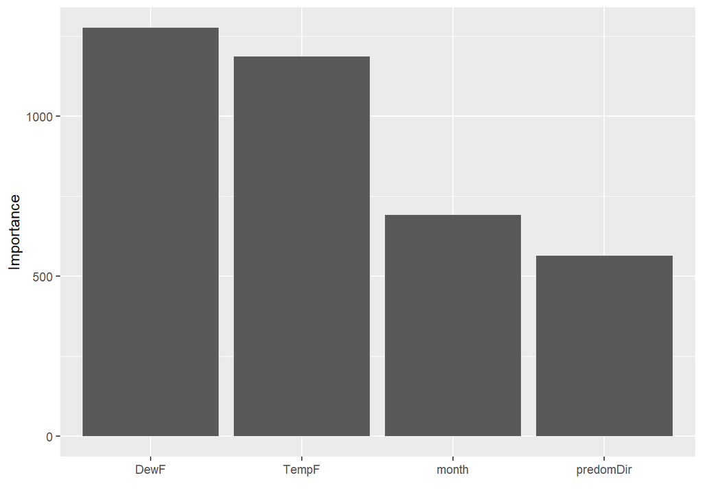

```r
caret::varImp(caretBest) %>%
    rownames_to_column() %>%
    ggplot(aes(x=fct_reorder(rowname, -Overall), y=Overall)) +
    geom_col() +
    labs(x="", y="Importance")
```

The mix of temperature and dew-point is the primary driver of the classiciations. There are many more “low confidence” (close voting) predictions for these two cities:

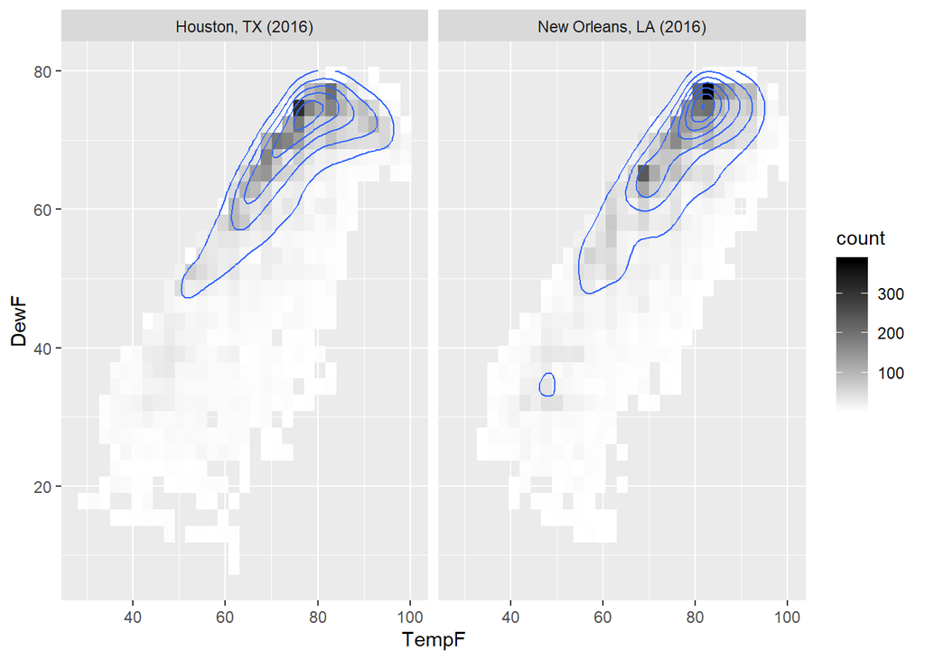

```r
ttLists$trainData %>%
    bind_rows(ttLists$testData) %>%
    ggplot(aes(x=TempF, y=DewF)) +
    geom_bin2d() +
    facet_wrap(~locale) +
    geom_density_2d() +
    scale_fill_continuous(low="white", high="black")
```

It is impressive that the model can tease out distinctions in data that are, at a glance, very similar.

#### *Temperature and Dew Point*

Suppose that the only information available about two cities were their temperatures and dew points. How well would a basic random forest, with mtry=2, classify the cities?

A function is written to take two locales and a random seed, create relevant test-train data, run a random forest model, make predictions, assess the accuracy, and return the relevant objects:

```r
# The createTestTrain function is updated to purely split an input dataframe
createTestTrain <- function(df,
                            testSize=0.3,
                            sortTrain=FALSE,
                            noNA=TRUE,
                            seed=NULL
                            ) {

    # FUNCTION ARGUMENTS:
    # df: the data frame or tibble for analysis
    # testSize: the proportion of the data to be used as test
    # sortTrain: boolean, whether to sort training indices to maintain the original order of training data
    # noNA: boolean, whether to include only complete cases
    # seed: the random seed to be used (NULL means no seed)

    # Filter out NA if requested
    if (noNA) {
        df <- df %>%
            filter(complete.cases(df))
    }

    # Get the desired number of train objects
    nTrain <- round((1-testSize) * nrow(df))

    # Set the random seed if it has been passed
    if (!is.null(seed)) { set.seed(seed) }

    # Get the indices for the training data
    idxTrain <- sample(1:nrow(df), size=nTrain, replace=FALSE)

    # Sort if requested
    if (sortTrain) { idxTrain <- sort(idxTrain) }

    # Return a list containing the train and test data
    list(trainData=df[idxTrain, ],
         testData=df[-idxTrain, ]
         )

}


# Run a random forest for two locales
rfTwoLocales <- function(df,
                         loc1,
                         loc2,
                         locVar="source",
                         otherVar="dtime",
                         vrbls=c("TempF", "DewF"),
                         pred="locale",
                         seed=NULL,
                         ntree=100,
                         mtry=NULL,
                         testSize=0.3
                         ) {

    # FUNCTION ARGUMENTS:
    # df: the data frame or tibble
    # loc1: the first locale
    # loc2: the second locale
    # locVar: the name of the variable where loc1 and loc2 can be found
    # otherVar: other variables to be kept, but not used in modeling
    # vrbls: explanatory variables for modeling
    # pred: predictor variable for modeling
    # seed: the random seed (NULL means no seed)
    # ntree: the number of trees to grow in the random forest
    # mtry: the splitting parameter for the random forest (NULL means use all variables)
    # testSize: proportion of data to use as test dataset

    # Filter df such that it includes only observations in loc1 or loc2
    # Select only the predictor and variables of interest
    dfModel <- df %>%
        filter(get(locVar) %in% c(loc1, loc2)) %>%
        select_at(vars(all_of(c(pred, otherVar, vrbls))))

    # Create the test-train split (will randomize using seed if provided)
    ttLists <- createTestTrain(dfModel, testSize=testSize, seed=seed)

    # Set the seed if requested
    if (!is.null(seed)) { set.seed(seed) }

    # Set mtry to be the length of the variables if not provided
    if (is.null(mtry)) { mtry <- length(vrbls) }

    # Run the random forest on the training data
    rfModel <- randomForest::randomForest(x=ttLists$trainData[, vrbls],
                                          y=factor(ttLists$trainData[, pred, drop=TRUE]),
                                          mtry=mtry,
                                          ntree=ntree
                                          )

    # Create predictions on the test data
    testPred <- predict(rfModel, ttLists$testData)

    # Augment the test data with the predictions
    testData <- ttLists$testData %>%
        mutate(predicted=testPred, correct=(testPred==get(pred)))

    # Grab the accuracy and accuracy by class

    # Return the objects as a list
    list(rfModel=rfModel,
         testData=testData,
         errorRate=colMeans(rfModel$err.rate)
         )

}
```

```r
# Create the file names to explore
names_2016 <- grep(x=names(cityNameMapper), pattern="_2016", value=TRUE)

# Create a container list to hold the output
list_2016_TempF_DewF <- vector("list", 0.5*length(names_2016)*(length(names_2016)-1))

n <- 1
for (ctr in 1:(length(names_2016)-1)) {
    for (ctr2 in (ctr+1):length(names_2016)) {
        list_2016_TempF_DewF[[n]] <- rfTwoLocales(metarData,
                                                  loc1=names_2016[ctr],
                                                  loc2=names_2016[ctr2],
                                                  vrbls=c("TempF", "DewF"),
                                                  ntree=25
                                                  )
        n <- n + 1
    }
}
```

Statistics about the overall accuracy can then be captured:

```r
# Helper function for map_dfr
helperAccuracyLocale <- function(x) {

    y <- x$errorRate
    tibble::tibble(locale1=names(y)[2],
                   locale2=names(y)[3],
                   accOverall=1-y[1],
                   accLocale1=1-y[2],
                   accLocale2=1-y[3]
                   )

}

# Create a tibble from the underlying accuracy data
acc_TempF_DewF <- map_dfr(list_2016_TempF_DewF, .f=helperAccuracyLocale)

# Assess the top 10 accuracy and the bottom 10 accuracy
acc_TempF_DewF %>%
    arrange(-accOverall) %>%
    head(10)
```

```
## # A tibble: 10 x 5
##    locale1                locale2               accOverall accLocale1 accLocale2
##    <chr>                  <chr>                      <dbl>      <dbl>      <dbl>
##  1 Green Bay, WI (2016)   Las Vegas, NV (2016)       0.897      0.893      0.901
##  2 Las Vegas, NV (2016)   New Orleans, LA (201~      0.890      0.903      0.877
##  3 Las Vegas, NV (2016)   Milwaukee, WI (2016)       0.888      0.887      0.889
##  4 Houston, TX (2016)     Las Vegas, NV (2016)       0.884      0.871      0.897
##  5 Las Vegas, NV (2016)   Madison, WI (2016)         0.879      0.892      0.866
##  6 Indianapolis, IN (201~ Las Vegas, NV (2016)       0.875      0.893      0.859
##  7 Chicago, IL (2016)     Las Vegas, NV (2016)       0.874      0.893      0.854
##  8 Grand Rapids, MI (201~ Las Vegas, NV (2016)       0.872      0.888      0.857
##  9 Las Vegas, NV (2016)   San Diego, CA (2016)       0.867      0.872      0.863
## 10 Las Vegas, NV (2016)   Traverse City, MI (2~      0.865      0.863      0.868
```

```r
acc_TempF_DewF %>%
    arrange(accOverall) %>%
    head(10)
```

```
## # A tibble: 10 x 5
##    locale1                locale2               accOverall accLocale1 accLocale2
##    <chr>                  <chr>                      <dbl>      <dbl>      <dbl>
##  1 Chicago, IL (2016)     Milwaukee, WI (2016)       0.539      0.574      0.505
##  2 Chicago, IL (2016)     Madison, WI (2016)         0.548      0.580      0.515
##  3 Detroit, MI (2016)     Grand Rapids, MI (20~      0.550      0.491      0.610
##  4 Detroit, MI (2016)     Lincoln, NE (2016)         0.551      0.589      0.513
##  5 Chicago, IL (2016)     Detroit, MI (2016)         0.552      0.522      0.581
##  6 Grand Rapids, MI (201~ Traverse City, MI (2~      0.553      0.595      0.511
##  7 Indianapolis, IN (201~ Lincoln, NE (2016)         0.554      0.595      0.513
##  8 Detroit, MI (2016)     Traverse City, MI (2~      0.558      0.496      0.619
##  9 Detroit, MI (2016)     Indianapolis, IN (20~      0.559      0.587      0.531
## 10 Green Bay, WI (2016)   Madison, WI (2016)         0.560      0.528      0.591
```

Of further interest is an overall accuracy by city:

```r
allAccuracy <- select(acc_TempF_DewF, locale=locale1, other=locale2, accOverall, accLocale=accLocale1) %>%
    bind_rows(select(acc_TempF_DewF, locale=locale2, other=locale1, accOverall, accLocale=accLocale2))

# Find the best match by locale
allAccuracy %>%
    group_by(locale) %>%
    top_n(accOverall, n=1) %>%
    arrange(-accOverall)
```

```
## # A tibble: 15 x 4
## # Groups:   locale [15]
##    locale                   other                accOverall accLocale
##    <chr>                    <chr>                     <dbl>     <dbl>
##  1 Green Bay, WI (2016)     Las Vegas, NV (2016)      0.897     0.893
##  2 Las Vegas, NV (2016)     Green Bay, WI (2016)      0.897     0.901
##  3 New Orleans, LA (2016)   Las Vegas, NV (2016)      0.890     0.877
##  4 Milwaukee, WI (2016)     Las Vegas, NV (2016)      0.888     0.889
##  5 Houston, TX (2016)       Las Vegas, NV (2016)      0.884     0.871
##  6 Madison, WI (2016)       Las Vegas, NV (2016)      0.879     0.866
##  7 Indianapolis, IN (2016)  Las Vegas, NV (2016)      0.875     0.893
##  8 Chicago, IL (2016)       Las Vegas, NV (2016)      0.874     0.893
##  9 Grand Rapids, MI (2016)  Las Vegas, NV (2016)      0.872     0.888
## 10 San Diego, CA (2016)     Las Vegas, NV (2016)      0.867     0.863
## 11 Traverse City, MI (2016) Las Vegas, NV (2016)      0.865     0.868
## 12 Detroit, MI (2016)       Las Vegas, NV (2016)      0.864     0.885
## 13 Minneapolis, MN (2016)   Las Vegas, NV (2016)      0.856     0.856
## 14 Lincoln, NE (2016)       Las Vegas, NV (2016)      0.845     0.833
## 15 Newark, NJ (2016)        Las Vegas, NV (2016)      0.809     0.812
```

```r
# Find the worst match by locale
allAccuracy %>%
    group_by(locale) %>%
    top_n(-accOverall, n=1) %>%
    arrange(accOverall)
```

```
## # A tibble: 15 x 4
## # Groups:   locale [15]
##    locale                   other                   accOverall accLocale
##    <chr>                    <chr>                        <dbl>     <dbl>
##  1 Chicago, IL (2016)       Milwaukee, WI (2016)         0.539     0.574
##  2 Milwaukee, WI (2016)     Chicago, IL (2016)           0.539     0.505
##  3 Madison, WI (2016)       Chicago, IL (2016)           0.548     0.515
##  4 Detroit, MI (2016)       Grand Rapids, MI (2016)      0.550     0.491
##  5 Grand Rapids, MI (2016)  Detroit, MI (2016)           0.550     0.610
##  6 Lincoln, NE (2016)       Detroit, MI (2016)           0.551     0.513
##  7 Traverse City, MI (2016) Grand Rapids, MI (2016)      0.553     0.511
##  8 Indianapolis, IN (2016)  Lincoln, NE (2016)           0.554     0.595
##  9 Green Bay, WI (2016)     Madison, WI (2016)           0.560     0.528
## 10 Minneapolis, MN (2016)   Madison, WI (2016)           0.568     0.555
## 11 Newark, NJ (2016)        Lincoln, NE (2016)           0.590     0.571
## 12 Houston, TX (2016)       New Orleans, LA (2016)       0.605     0.542
## 13 New Orleans, LA (2016)   Houston, TX (2016)           0.605     0.667
## 14 San Diego, CA (2016)     Minneapolis, MN (2016)       0.764     0.834
## 15 Las Vegas, NV (2016)     Newark, NJ (2016)            0.809     0.806
```

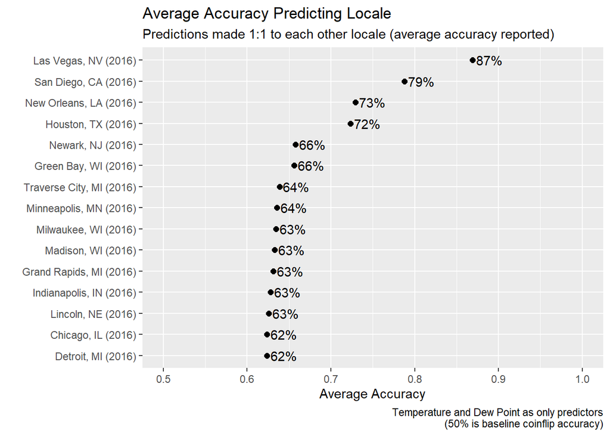

```r
# Overall accuracy by location plot
allAccuracy %>%
    group_by(locale) %>%
    summarize_if(is.numeric, mean) %>%
    ggplot(aes(x=fct_reorder(locale, accOverall), y=accOverall)) +
    geom_point(size=2) +
    geom_text(aes(y=accOverall+0.02, label=paste0(round(100*accOverall), "%"))) +
    coord_flip() +
    labs(x="",
         y="Average Accuracy",
         title="Average Accuracy Predicting Locale",
         subtitle="Predictions made 1:1 to each other locale (average accuracy reported)",
         caption="Temperature and Dew Point as only predictors\n(50% is baseline coinflip accuracy)"
         ) +
    ylim(c(0.5, 1))
```

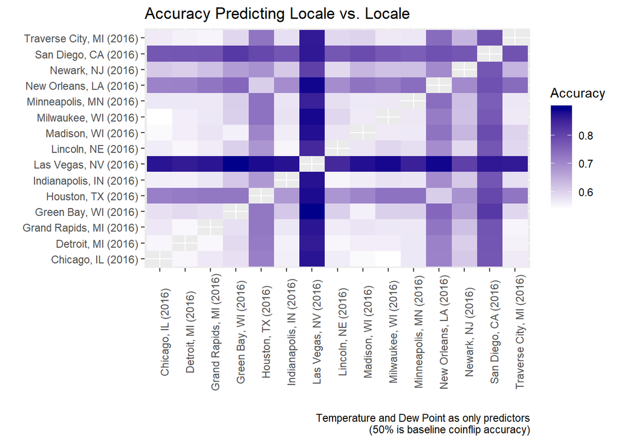

```r
# Overall accuracy heatmap
allAccuracy %>%
    ggplot(aes(x=locale, y=other)) +
    geom_tile(aes(fill=accOverall)) +
    theme(axis.text.x=element_text(angle=90)) +
    scale_fill_continuous("Accuracy", high="darkblue", low="white") +
    labs(title="Accuracy Predicting Locale vs. Locale",
         caption="Temperature and Dew Point as only predictors\n(50% is baseline coinflip accuracy)",
         x="",
         y=""
         )
```

One hypothesis is that adding month as a predictor may help for distinguishing cities in different climates. For example, summer in the warm season in Detroit may look like spring/fall in Houston or New Orleans:

```r
# Create a container list to hold the output
list_2016_TempF_DewF_month <- vector("list", 0.5*length(names_2016)*(length(names_2016)-1))

n <- 1
for (ctr in 1:(length(names_2016)-1)) {
    for (ctr2 in (ctr+1):length(names_2016)) {
        list_2016_TempF_DewF_month[[n]] <- rfTwoLocales(metarData,
                                                        loc1=names_2016[ctr],
                                                        loc2=names_2016[ctr2],
                                                        vrbls=c("TempF", "DewF", "month"),
                                                        ntree=25
                                                        )
        n <- n + 1
    }
}
```

Accuracy can then be assessed:

```r
# Create a tibble from the underlying accuracy data
acc_TempF_DewF_month <- map_dfr(list_2016_TempF_DewF_month, .f=helperAccuracyLocale)

# Assess the top 10 accuracy and the bottom 10 accuracy
acc_TempF_DewF_month %>%
    arrange(-accOverall) %>%
    head(10)
```

```
## # A tibble: 10 x 5
##    locale1                locale2               accOverall accLocale1 accLocale2
##    <chr>                  <chr>                      <dbl>      <dbl>      <dbl>
##  1 Green Bay, WI (2016)   Las Vegas, NV (2016)       0.961      0.960      0.961
##  2 Las Vegas, NV (2016)   Madison, WI (2016)         0.949      0.952      0.945
##  3 Las Vegas, NV (2016)   Milwaukee, WI (2016)       0.944      0.947      0.941
##  4 New Orleans, LA (2016) Traverse City, MI (2~      0.941      0.946      0.937
##  5 Las Vegas, NV (2016)   Traverse City, MI (2~      0.940      0.940      0.939
##  6 Minneapolis, MN (2016) New Orleans, LA (201~      0.939      0.941      0.938
##  7 Green Bay, WI (2016)   New Orleans, LA (201~      0.938      0.931      0.944
##  8 Grand Rapids, MI (201~ Las Vegas, NV (2016)       0.937      0.939      0.934
##  9 Houston, TX (2016)     Traverse City, MI (2~      0.935      0.938      0.931
## 10 Las Vegas, NV (2016)   Minneapolis, MN (201~      0.935      0.938      0.931
```

```r
acc_TempF_DewF_month %>%
    arrange(accOverall) %>%
    head(10)
```

```
## # A tibble: 10 x 5
##    locale1                locale2               accOverall accLocale1 accLocale2
##    <chr>                  <chr>                      <dbl>      <dbl>      <dbl>
##  1 Chicago, IL (2016)     Milwaukee, WI (2016)       0.578      0.619      0.536
##  2 Detroit, MI (2016)     Grand Rapids, MI (20~      0.584      0.605      0.564
##  3 Grand Rapids, MI (201~ Traverse City, MI (2~      0.598      0.623      0.574
##  4 Chicago, IL (2016)     Madison, WI (2016)         0.600      0.630      0.569
##  5 Green Bay, WI (2016)   Madison, WI (2016)         0.602      0.631      0.573
##  6 Chicago, IL (2016)     Grand Rapids, MI (20~      0.606      0.580      0.631
##  7 Grand Rapids, MI (201~ Madison, WI (2016)         0.608      0.590      0.626
##  8 Madison, WI (2016)     Milwaukee, WI (2016)       0.610      0.641      0.580
##  9 Chicago, IL (2016)     Detroit, MI (2016)         0.612      0.666      0.558
## 10 Chicago, IL (2016)     Indianapolis, IN (20~      0.613      0.637      0.590
```

```r
allAccuracy_month <- select(acc_TempF_DewF_month,
                            locale=locale1,
                            other=locale2,
                            accOverall,
                            accLocale=accLocale1
                            ) %>%
    bind_rows(select(acc_TempF_DewF_month,
                     locale=locale2,
                     other=locale1,
                     accOverall,
                     accLocale=accLocale2
                     )
              )

# Find the best match by locale
allAccuracy_month %>%
    group_by(locale) %>%
    top_n(accOverall, n=1) %>%
    arrange(-accOverall)
```

```
## # A tibble: 15 x 4
## # Groups:   locale [15]
##    locale                   other                    accOverall accLocale
##    <chr>                    <chr>                         <dbl>     <dbl>
##  1 Green Bay, WI (2016)     Las Vegas, NV (2016)          0.961     0.960
##  2 Las Vegas, NV (2016)     Green Bay, WI (2016)          0.961     0.961
##  3 Madison, WI (2016)       Las Vegas, NV (2016)          0.949     0.945
##  4 Milwaukee, WI (2016)     Las Vegas, NV (2016)          0.944     0.941
##  5 New Orleans, LA (2016)   Traverse City, MI (2016)      0.941     0.946
##  6 Traverse City, MI (2016) New Orleans, LA (2016)        0.941     0.937
##  7 Minneapolis, MN (2016)   New Orleans, LA (2016)        0.939     0.941
##  8 Grand Rapids, MI (2016)  Las Vegas, NV (2016)          0.937     0.939
##  9 Houston, TX (2016)       Traverse City, MI (2016)      0.935     0.938
## 10 Chicago, IL (2016)       Las Vegas, NV (2016)          0.933     0.933
## 11 Detroit, MI (2016)       Las Vegas, NV (2016)          0.928     0.928
## 12 Indianapolis, IN (2016)  Las Vegas, NV (2016)          0.920     0.927
## 13 San Diego, CA (2016)     Las Vegas, NV (2016)          0.910     0.900
## 14 Lincoln, NE (2016)       Las Vegas, NV (2016)          0.906     0.907
## 15 Newark, NJ (2016)        New Orleans, LA (2016)        0.873     0.858
```

```r
# Find the worst match by locale
allAccuracy_month %>%
    group_by(locale) %>%
    top_n(-accOverall, n=1) %>%
    arrange(accOverall)
```

```
## # A tibble: 15 x 4
## # Groups:   locale [15]
##    locale                   other                   accOverall accLocale
##    <chr>                    <chr>                        <dbl>     <dbl>
##  1 Chicago, IL (2016)       Milwaukee, WI (2016)         0.578     0.619
##  2 Milwaukee, WI (2016)     Chicago, IL (2016)           0.578     0.536
##  3 Detroit, MI (2016)       Grand Rapids, MI (2016)      0.584     0.605
##  4 Grand Rapids, MI (2016)  Detroit, MI (2016)           0.584     0.564
##  5 Traverse City, MI (2016) Grand Rapids, MI (2016)      0.598     0.574
##  6 Madison, WI (2016)       Chicago, IL (2016)           0.600     0.569
##  7 Green Bay, WI (2016)     Madison, WI (2016)           0.602     0.631
##  8 Indianapolis, IN (2016)  Chicago, IL (2016)           0.613     0.590
##  9 Lincoln, NE (2016)       Indianapolis, IN (2016)      0.618     0.559
## 10 Minneapolis, MN (2016)   Madison, WI (2016)           0.626     0.611
## 11 Houston, TX (2016)       New Orleans, LA (2016)       0.640     0.643
## 12 New Orleans, LA (2016)   Houston, TX (2016)           0.640     0.637
## 13 Newark, NJ (2016)        Indianapolis, IN (2016)      0.662     0.678
## 14 San Diego, CA (2016)     Indianapolis, IN (2016)      0.846     0.857
## 15 Las Vegas, NV (2016)     Newark, NJ (2016)            0.872     0.872
```

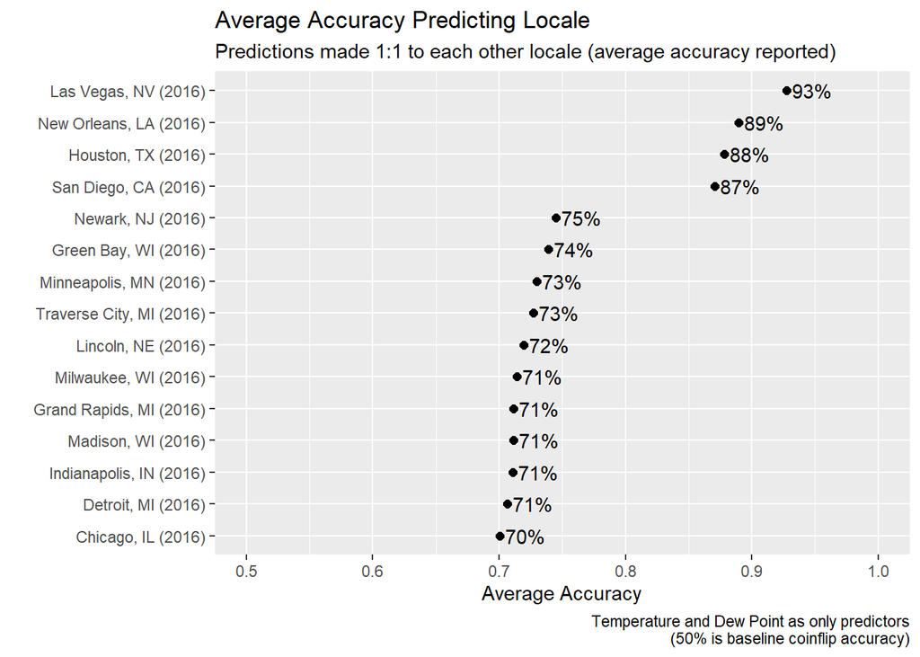

```r
# Overall accuracy by location plot
allAccuracy_month %>%
    group_by(locale) %>%
    summarize_if(is.numeric, mean) %>%
    ggplot(aes(x=fct_reorder(locale, accOverall), y=accOverall)) +
    geom_point(size=2) +
    geom_text(aes(y=accOverall+0.02, label=paste0(round(100*accOverall), "%"))) +
    coord_flip() +
    labs(x="",
         y="Average Accuracy",
         title="Average Accuracy Predicting Locale",
         subtitle="Predictions made 1:1 to each other locale (average accuracy reported)",
         caption="Temperature and Dew Point as only predictors\n(50% is baseline coinflip accuracy)"
         ) +
    ylim(c(0.5, 1))
```

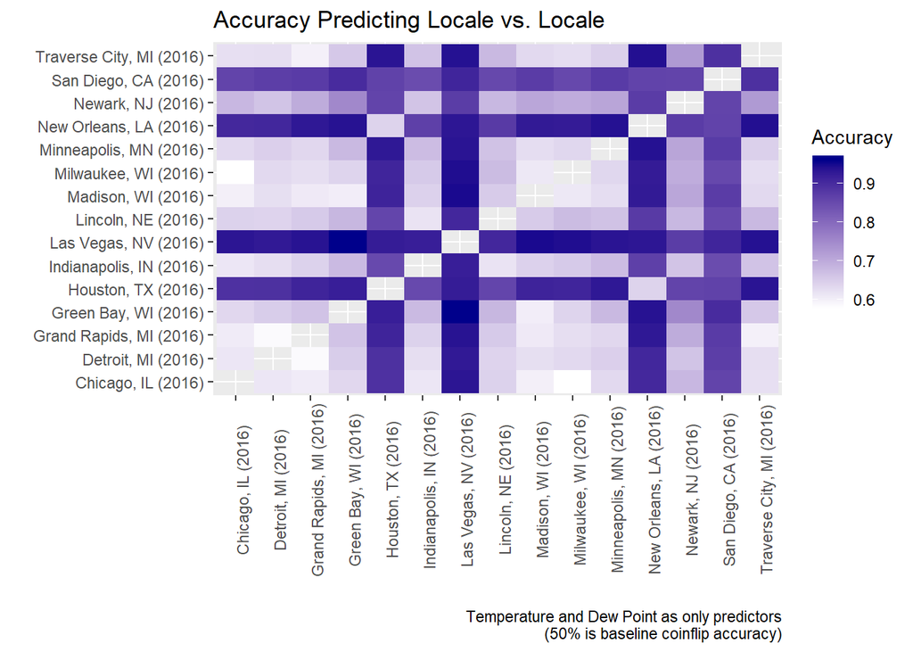

```r
# Overall accuracy heatmap
allAccuracy_month %>%
    ggplot(aes(x=locale, y=other)) +
    geom_tile(aes(fill=accOverall)) +
    theme(axis.text.x=element_text(angle=90)) +
    scale_fill_continuous("Accuracy", high="darkblue", low="white") +
    labs(title="Accuracy Predicting Locale vs. Locale",
         caption="Temperature and Dew Point as only predictors\n(50% is baseline coinflip accuracy)",
         x="",
         y=""
         )
```

Accuracies are meaningfully higher. Of interest, there is a new group of highly differentiated locales, including New Orleans/Houston vs. Traverse City/Minneapolis. As hypothesized, adding month significantly aids in differentiating wintry cities from hot-humid cities, as summer in a wintry city may otherwise be hard to distinguish from spring/fall in a hot-humid city.

In fact, with the exception of Houston vs. New Orleans, there appears to be very good differentiation for each of Las Vegas, San Diego, Hoston, and New Orleans from all other locales.

Change in accuracy can also be plotted:

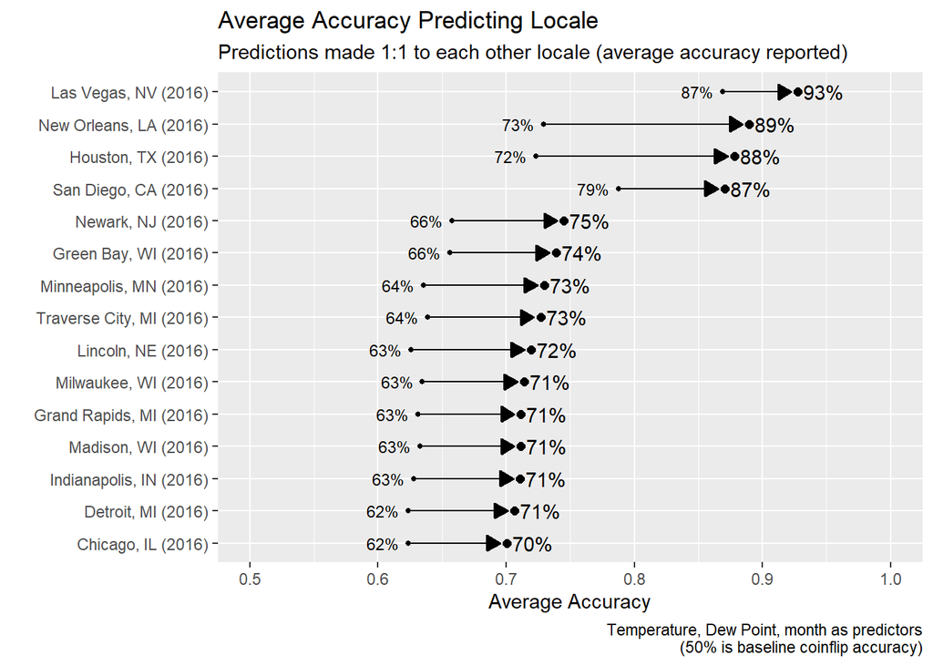

```r
# Pull the accuracies for the two different models
x1 <- allAccuracy %>%
    group_by(locale) %>%
    summarize(acc1=mean(accOverall))
x2 <- allAccuracy_month %>%
    group_by(locale) %>%
    summarize(acc2=mean(accOverall))

# Merge accuracy data and plot
x1 %>%
    inner_join(x2, by="locale") %>%
    ggplot(aes(x=fct_reorder(locale, acc2))) +
    geom_point(aes(y=acc2), size=2) +
    geom_point(aes(y=acc1), size=1) +
    geom_text(aes(y=acc2+0.02, label=paste0(round(100*acc2), "%"))) +
    geom_text(aes(y=acc1-0.02, label=paste0(round(100*acc1), "%")), size=3) +
    geom_segment(aes(xend=fct_reorder(locale, acc2), y=acc1, yend=acc2-0.005),
                 arrow=arrow(length=unit(0.3, "cm"), type="closed")
                 ) +
    coord_flip() +
    labs(x="",
         y="Average Accuracy",
         title="Average Accuracy Predicting Locale",
         subtitle="Predictions made 1:1 to each other locale (average accuracy reported)",
         caption="Temperature, Dew Point, month as predictors\n(50% is baseline coinflip accuracy)"
         ) +
    ylim(c(0.5, 1))
```

The increase in accuracy is particularly striking for New Orleans and Houston.

Next, the simple model is run to classify locale across the full dataset. The rfTwoLocales() function can be called in a slightly modified manner for this purpose:

```r
# Run random forest for multiple locales
rfMultiLocale <- function(tbl,
                          vrbls,
                          locs=NULL,
                          locVar="source",
                          otherVar="dtime",
                          pred="locale",
                          seed=NULL,
                          ntree=100,
                          mtry=NULL,
                          testSize=0.3
                          ) {

    # FUNCTION ARGUMENTS:
    # df: the data frame or tibble
    # vrbls: explanatory variables for modeling
    # locs: the locations to use (NULL means all)
    # locVar: the name of the variable where locs can be found
    # otherVar: other variables to be kept, but not used in modeling
    # pred: predictor variable for modeling
    # seed: the random seed (NULL means no seed)
    # ntree: the number of trees to grow in the random forest
    # mtry: the splitting parameter for the random forest (NULL means use all variables)
    # testSize: the fractional portion of data that should be used as the test dataset

    # Create locs if it has not been passed
    if (is.null(locs)) {
        locs <- tbl %>% pull(locVar) %>% unique() %>% sort()
        cat("\nRunning for locations:\n")
        print(locs)
    }

    # Pass to rfTwoLocales
    rfOut <- rfTwoLocales(tbl,
                          loc1=locs,
                          loc2=c(),
                          locVar=locVar,
                          otherVar=otherVar,
                          vrbls=vrbls,
                          pred=pred,
                          seed=seed,
                          ntree=ntree,
                          mtry=mtry,
                          testSize=testSize
                          )

    # Return the list object
    rfOut

}
```

The function can then be applied to the 2016 data:

```r
# Run random forest for all 2016 locales
rf_all_2016_TDm <- rfMultiLocale(metarData,
                                 vrbls=c("TempF", "DewF", "month"),
                                 locs=names_2016,
                                 ntree=50,
                                 seed=2006201341
                                 )
```

Summaries can then be created for the accuracy in predicting each locale:

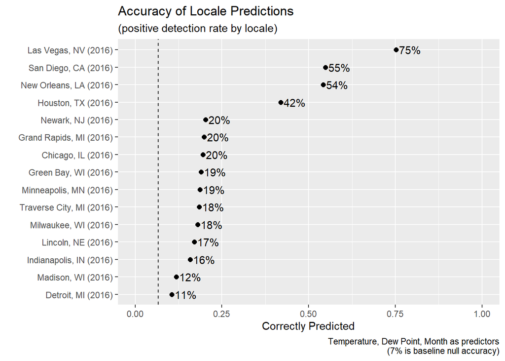

```r
# Create summary of accuracy
all2016Accuracy <- rf_all_2016_TDm$testData %>%
    mutate(locale=factor(locale, levels=levels(predicted))) %>%
    count(locale, predicted, correct) %>%
    group_by(locale) %>%
    mutate(pct=n/sum(n)) %>%
    ungroup()

# Calculate the number of levels
nLevels <- length(levels(factor(all2016Accuracy$locale)))
nullAcc <- 1 / nLevels

# Create plot for overall accuracy
all2016Accuracy %>%
    filter(locale==predicted) %>%
    ggplot(aes(x=fct_reorder(locale, pct))) +
    geom_point(aes(y=pct), size=2) +
    geom_text(aes(y=pct+0.04, label=paste0(round(100*pct), "%"))) +
    geom_hline(aes(yintercept=nullAcc), lty=2) +
    coord_flip() +
    ylim(0, 1) +
    labs(x="",
         y="Correctly Predicted",
         title="Accuracy of Locale Predictions",
         subtitle="(positive detection rate by locale)",
         caption=paste0("Temperature, Dew Point, Month as predictors\n(",
                        round(100*nullAcc),
                        "% is baseline null accuracy)"
                        )
         )
```

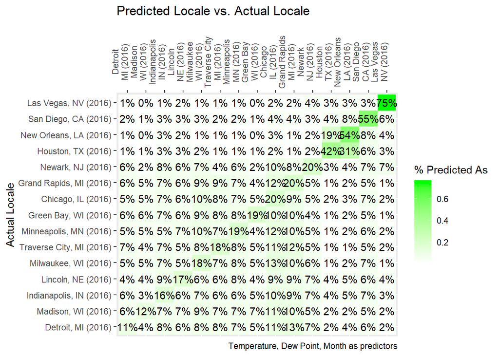

```r
# Order locales sensibly
locOrder <- all2016Accuracy %>%
    filter(correct) %>%
    arrange(pct) %>%
    pull(locale)

# Create plot for which locales are classified as each other
all2016Accuracy %>%
    mutate(locale=factor(locale, levels=locOrder),
           predPretty=factor(str_replace(predicted, pattern=", ", replacement="\n"),
                             levels=str_replace(locOrder, pattern=", ", replacement="\n")
                             )
           ) %>%
    ggplot(aes(y=locale, x=predPretty)) +
    geom_tile(aes(fill=pct)) +
    geom_text(aes(label=paste0(round(100*pct), "%"))) +
    scale_fill_continuous("% Predicted As", low="white", high="green") +
    scale_x_discrete(position="top") +
    theme(axis.text.x=element_text(angle=90)) +
    labs(x="",
         y="Actual Locale",
         title="Predicted Locale vs. Actual Locale",
         caption="Temperature, Dew Point, Month as predictors"
         )
```

The model is fairly accurate in predicting Las Vegas and San Diego. The model frequently predicts Houston and New Orleans as one of the group, but often classifying one locale as the other.

Accuracy is much lower for many of the cold wether cities. While there is improvement relative to the null accuracy, there is significant overlap in the temperature and dew point by month.

Clouds (minimum levels and ceiling heights) can potentially help further differentiate the cold weather cities on the downwind side of the lake, as well as helping to further pull apart Las Vegas (almost always clear) and San Diego (frequent marine layer).

A helper function is built to map cloud heights to buckets, then minimum cloud height and ceiling are added to the model:

```r
# Convert cloud height to buckets and factor
mapCloudHeight <- function(x) {

    factor(case_when(x==-100 ~ "None",
                     x <= 1000 ~ "Surface",
                     x <= 3000 ~ "Low",
                     x <= 6000 ~ "Medium",
                     x <= 12000 ~ "High",
                     TRUE ~ "Error"
                     ),
           levels=c("Surface", "Low", "Medium", "High", "None")
           )

}

# Apply to metarData and keep variables of interest
modData <- metarData %>%
    mutate(minHeight=mapCloudHeight(minHeight), ceilingHeight=mapCloudHeight(ceilingHeight))
```

An updated random forest model is then run:

```r
# Run random forest for all 2016 locales
rf_all_2016_TDmc <- rfMultiLocale(modData,
                                  vrbls=c("TempF", "DewF", "month", "minHeight", "ceilingHeight"),
                                  locs=names_2016,
                                  ntree=50,
                                  seed=2006201355
                                  )
```

The evaluation process is converted to a function:

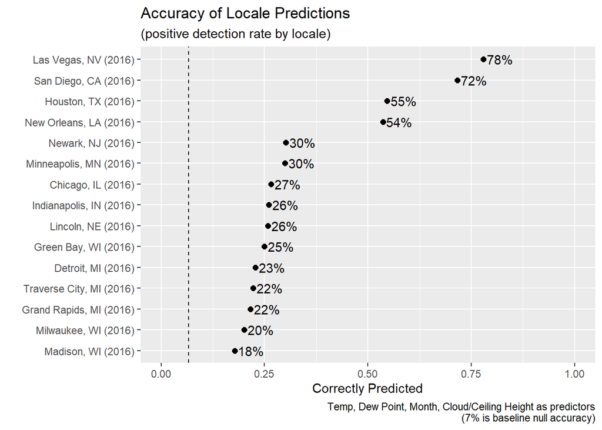

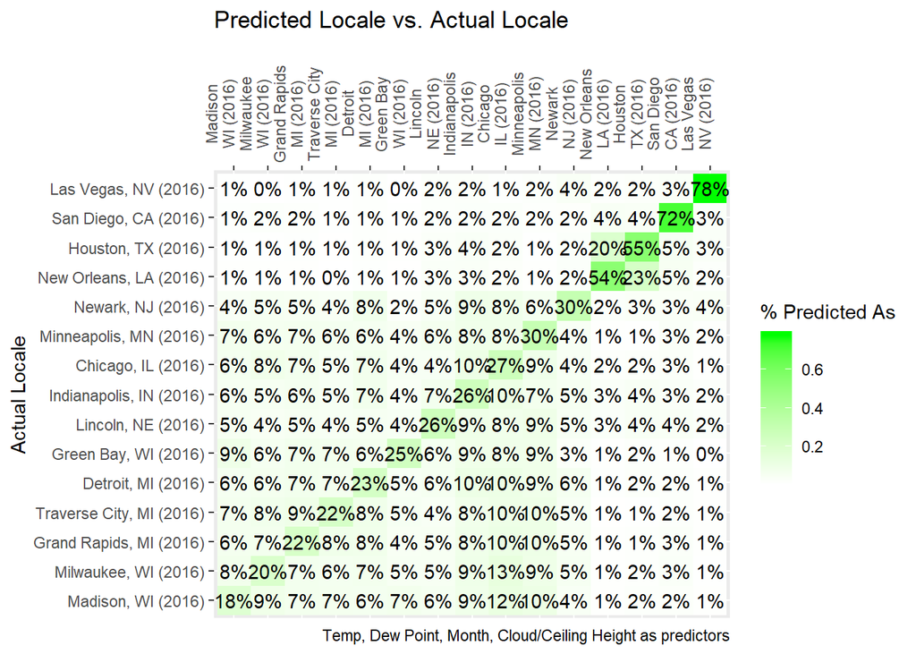

```
## # A tibble: 225 x 5
##    locale             predicted               correct     n    pct
##    <fct>              <fct>                   <lgl>   <int>  <dbl>
##  1 Chicago, IL (2016) Chicago, IL (2016)      TRUE      706 0.266
##  2 Chicago, IL (2016) Detroit, MI (2016)      FALSE     197 0.0742
##  3 Chicago, IL (2016) Grand Rapids, MI (2016) FALSE     180 0.0678
##  4 Chicago, IL (2016) Green Bay, WI (2016)    FALSE     119 0.0448
##  5 Chicago, IL (2016) Houston, TX (2016)      FALSE      56 0.0211
##  6 Chicago, IL (2016) Indianapolis, IN (2016) FALSE     263 0.0991
##  7 Chicago, IL (2016) Las Vegas, NV (2016)    FALSE      28 0.0105
##  8 Chicago, IL (2016) Lincoln, NE (2016)      FALSE     119 0.0448
##  9 Chicago, IL (2016) Madison, WI (2016)      FALSE     168 0.0633
## 10 Chicago, IL (2016) Milwaukee, WI (2016)    FALSE     220 0.0829
## # ... with 215 more rows
```

```r
# Evaluate model predictions
evalPredictions <- function(lst,
                            plotCaption,
                            keyVar="locale"
                            ) {

    # FUNCTION ARGUMENTS:
    # lst: the list containing outputs of the modeling
    # plotCaption: description of predictors used
    # keyVar: the variable that represents truth when assessing predictions

    # Create summary of accuracy
    all2016Accuracy <- lst$testData %>%
        mutate(locale=factor(get(keyVar), levels=levels(predicted))) %>%
        count(locale, predicted, correct) %>%
        group_by(locale) %>%
        mutate(pct=n/sum(n)) %>%
        ungroup()

    # Calculate the number of levels
    nLevels <- length(levels(factor(all2016Accuracy$locale)))
    nullAcc <- 1 / nLevels

    # Create plot for overall accuracy
    p1 <- all2016Accuracy %>%
        filter(locale==predicted) %>%
        ggplot(aes(x=fct_reorder(locale, pct))) +
        geom_point(aes(y=pct), size=2) +
        geom_text(aes(y=pct+0.04, label=paste0(round(100*pct), "%"))) +
        geom_hline(aes(yintercept=nullAcc), lty=2) +
        coord_flip() +
        ylim(0, 1) +
        labs(x="",
             y="Correctly Predicted",
             title="Accuracy of Locale Predictions",
             subtitle="(positive detection rate by locale)",
             caption=paste0(plotCaption,
                            " as predictors\n(",
                            round(100*nullAcc),
                            "% is baseline null accuracy)"
                            )
             )
    print(p1)

    # Order locales sensibly
    locOrder <- all2016Accuracy %>%
        filter(correct) %>%
        arrange(pct) %>%
        pull(locale)

    # Create plot for which locales are classified as each other
    p2 <- all2016Accuracy %>%
        mutate(locale=factor(locale, levels=locOrder),
               predPretty=factor(str_replace(predicted, pattern=", ", replacement="\n"),
                                 levels=str_replace(locOrder, pattern=", ", replacement="\n")
                                 )
               ) %>%
        ggplot(aes(y=locale, x=predPretty)) +
        geom_tile(aes(fill=pct)) +
        geom_text(aes(label=paste0(round(100*pct), "%"))) +
        scale_fill_continuous("% Predicted As", low="white", high="green") +
        scale_x_discrete(position="top") +
        theme(axis.text.x=element_text(angle=90)) +
        labs(x="",
             y="Actual Locale",
             title="Predicted Locale vs. Actual Locale",
             caption=paste0(plotCaption, " as predictors")
             )
    print(p2)

    # Return the accuracy object
    all2016Accuracy

}

evalPredictions(rf_all_2016_TDmc, plotCaption = "Temp, Dew Point, Month, Cloud/Ceiling Height")
```

Accuracy increases, especially for San Diego and several of the cold wether cities.

The model can also be built out to consider wind speed and wind direction. No attempt yet is made to control for over-fitting:

```r
# Run random forest for all 2016 locales
rf_all_2016_TDmcw <- rfMultiLocale(modData,
                                   vrbls=c("TempF", "DewF",
                                           "month",
                                           "minHeight", "ceilingHeight",
                                           "WindSpeed", "predomDir"
                                           ),
                                   locs=names_2016,
                                   ntree=50,
                                   seed=2006201355
                                   )
```

The evaluation process can again be run:

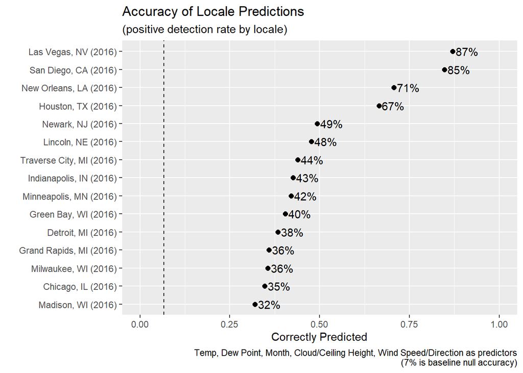

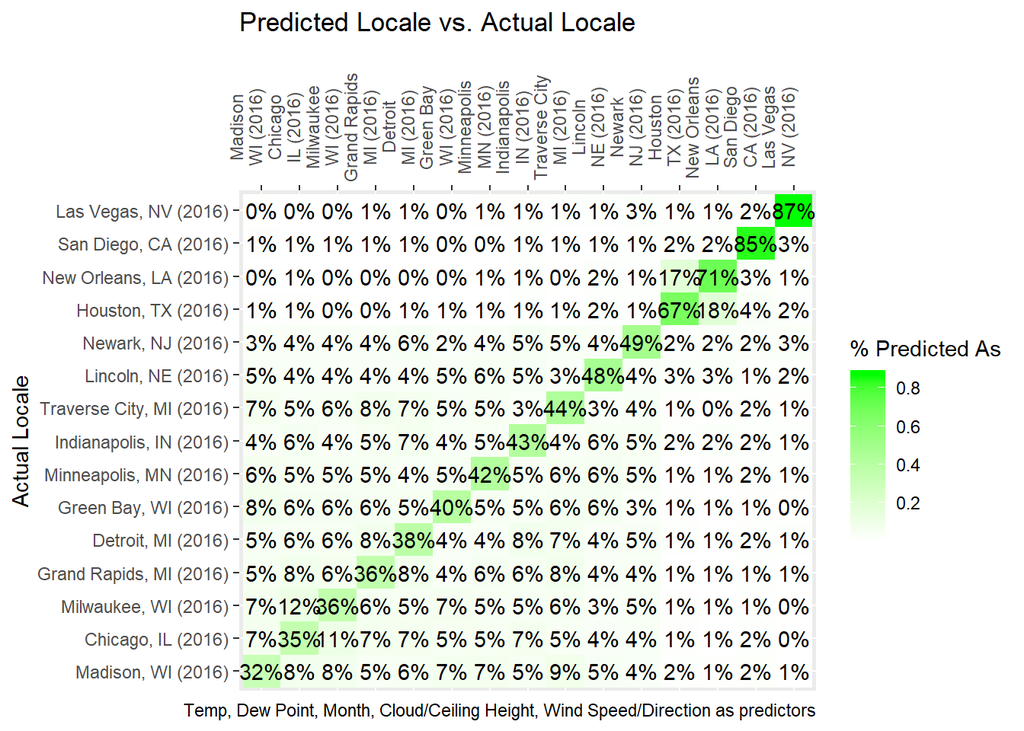

```
## # A tibble: 225 x 5
##    locale             predicted               correct     n     pct
##    <fct>              <fct>                   <lgl>   <int>   <dbl>
##  1 Chicago, IL (2016) Chicago, IL (2016)      TRUE      922 0.347
##  2 Chicago, IL (2016) Detroit, MI (2016)      FALSE     179 0.0674
##  3 Chicago, IL (2016) Grand Rapids, MI (2016) FALSE     186 0.0701
##  4 Chicago, IL (2016) Green Bay, WI (2016)    FALSE     139 0.0524
##  5 Chicago, IL (2016) Houston, TX (2016)      FALSE      28 0.0105
##  6 Chicago, IL (2016) Indianapolis, IN (2016) FALSE     186 0.0701
##  7 Chicago, IL (2016) Las Vegas, NV (2016)    FALSE       8 0.00301
##  8 Chicago, IL (2016) Lincoln, NE (2016)      FALSE     101 0.0380
##  9 Chicago, IL (2016) Madison, WI (2016)      FALSE     183 0.0689
## 10 Chicago, IL (2016) Milwaukee, WI (2016)    FALSE     285 0.107
## # ... with 215 more rows
```

```r
evalPredictions(rf_all_2016_TDmcw,
                plotCaption = "Temp, Dew Point, Month, Cloud/Ceiling Height, Wind Speed/Direction"
                )
```

Including wind significantly improves model accuracy for most locales. Even the cold weather cities are now being predicted with 33%-50% accurcay.

Next, a smaller subset of the weather data is explored, with the cities grouped as:

- Las Vegas
- San Diego
- New Orleans / Houston
- Newark
- Lincoln
- Traverse City / Grand Rapids / Detroit
- Chicago / Milwaukee / Madison / Green Bay / Minneapolis / Indianapolis

Further, a variable will be created for “hr”, the Zulu hour of the observation:

```r
locale2016Mapper <- c('Cold-MI', 'Newark', 'Cold', 'Cold-MI', 'Humid', 'Cold', 'Desert', 'Lincoln', 'Cold', 'Cold', 'Cold', 'Humid', 'Cold', 'Marine', 'Cold-MI')
names(locale2016Mapper) <- c('Detroit, MI (2016)', 'Newark, NJ (2016)', 'Green Bay, WI (2016)', 'Grand Rapids, MI (2016)', 'Houston, TX (2016)', 'Indianapolis, IN (2016)', 'Las Vegas, NV (2016)', 'Lincoln, NE (2016)', 'Milwaukee, WI (2016)', 'Madison, WI (2016)', 'Minneapolis, MN (2016)', 'New Orleans, LA (2016)', 'Chicago, IL (2016)', 'San Diego, CA (2016)', 'Traverse City, MI (2016)')

tibble::tibble(locale=names(locale2016Mapper), mapping=locale2016Mapper) %>%
    arrange(mapping, locale)
```

```
## # A tibble: 15 x 2
##    locale                   mapping
##    <chr>                    <chr>
##  1 Chicago, IL (2016)       Cold
##  2 Green Bay, WI (2016)     Cold
##  3 Indianapolis, IN (2016)  Cold
##  4 Madison, WI (2016)       Cold
##  5 Milwaukee, WI (2016)     Cold
##  6 Minneapolis, MN (2016)   Cold
##  7 Detroit, MI (2016)       Cold-MI
##  8 Grand Rapids, MI (2016)  Cold-MI
##  9 Traverse City, MI (2016) Cold-MI
## 10 Las Vegas, NV (2016)     Desert
## 11 Houston, TX (2016)       Humid
## 12 New Orleans, LA (2016)   Humid
## 13 Lincoln, NE (2016)       Lincoln
## 14 San Diego, CA (2016)     Marine
## 15 Newark, NJ (2016)        Newark
```

```r
modData <- modData %>%
    mutate(hr=lubridate::hour(dtime),
           locType=locale2016Mapper[locale]
           )

modData %>%
    count(locType, year) %>%
    pivot_wider(locType, names_from="year", values_from="n")
```

```
## # A tibble: 8 x 4
##   locType `2016` `2015` `2017`
##   <chr>    <int>  <int>  <int>
## 1 Cold     52521     NA     NA
## 2 Cold-MI  26300     NA     NA
## 3 Desert    8770     NA     NA
## 4 Humid    17535     NA     NA
## 5 Lincoln   8765     NA     NA
## 6 Marine    8762     NA     NA
## 7 Newark    8773     NA     NA
## 8 <NA>        NA  34919  34871
```

The data are the filtered so that there are an equal number of observations from each locale type. The model can later be predicted against the remaining items:

```r
# Set a seed for reporducibility
set.seed(2006211352)

# Find the smallest locale type
nSmall <- modData %>%
    filter(!is.na(locType)) %>%
    count(locType) %>%
    pull(n) %>%
    min()

# Create the relevant data subset
subData <- modData %>%
    filter(!is.na(locType)) %>%
    group_by(locType) %>%
    sample_n(size=nSmall, replace=FALSE) %>%
    ungroup()

# Sumarize the data subset
subData %>%
    count(locale) %>%
    arrange(-n)
```

```
## # A tibble: 15 x 2
##    locale                       n
##    <chr>                    <int>
##  1 Las Vegas, NV (2016)      8762
##  2 Lincoln, NE (2016)        8762
##  3 Newark, NJ (2016)         8762
##  4 San Diego, CA (2016)      8762
##  5 New Orleans, LA (2016)    4401
##  6 Houston, TX (2016)        4361
##  7 Grand Rapids, MI (2016)   2953
##  8 Traverse City, MI (2016)  2951
##  9 Detroit, MI (2016)        2858
## 10 Milwaukee, WI (2016)      1503
## 11 Chicago, IL (2016)        1482
## 12 Minneapolis, MN (2016)    1473
## 13 Madison, WI (2016)        1452
## 14 Green Bay, WI (2016)      1439
## 15 Indianapolis, IN (2016)   1413
```

The previous model can then be run on the data subset:

```r
# Run random forest for all 2016 locale types
rf_types_2016_TDmcw <- rfMultiLocale(subData,
                                     vrbls=c("TempF", "DewF",
                                             "month",
                                             "minHeight", "ceilingHeight",
                                             "WindSpeed", "predomDir"
                                             ),
                                     locs=NULL,
                                     locVar="locType",
                                     pred="locType",
                                     ntree=50,
                                     seed=2006211401
                                     )
```

```
##
## Running for locations:
## [1] "Cold"    "Cold-MI" "Desert"  "Humid"   "Lincoln" "Marine"  "Newark"
```

The evaluation process can again be run:

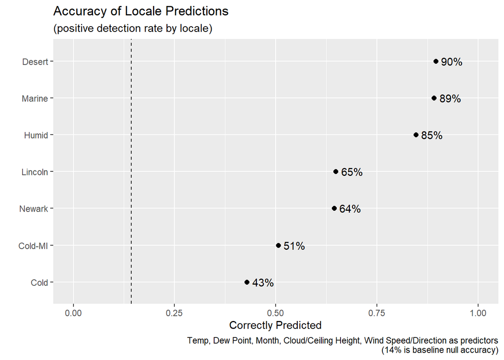

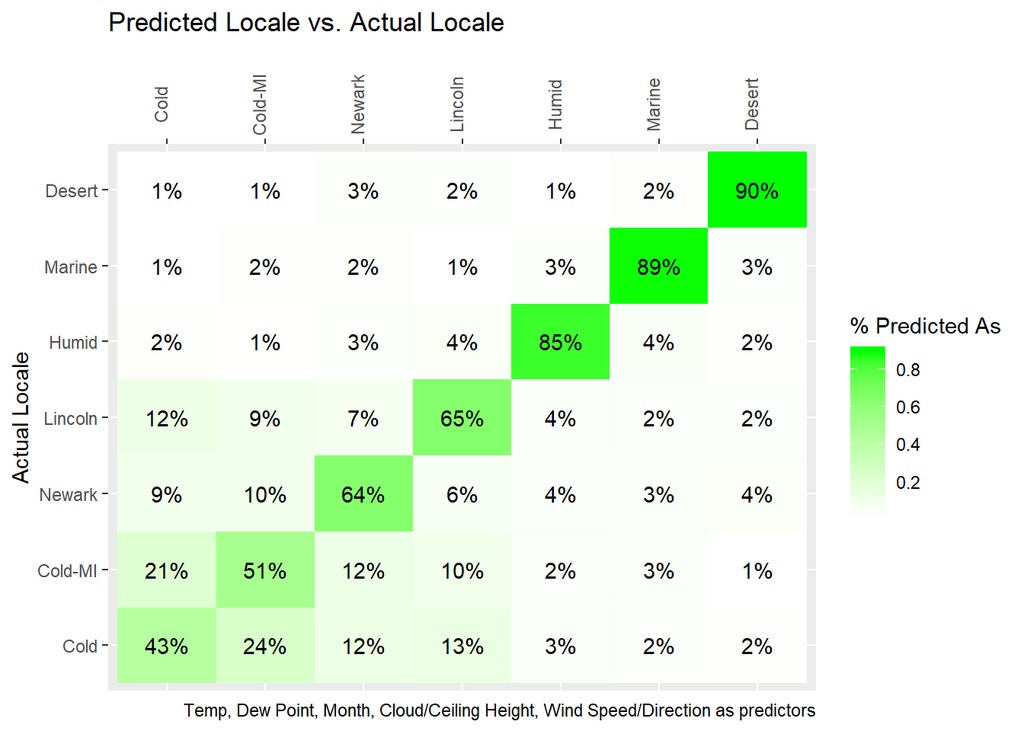

```
## # A tibble: 49 x 5
##    locale  predicted correct     n    pct
##    <fct>   <fct>     <lgl>   <int>  <dbl>
##  1 Cold    Cold      TRUE     1127 0.429
##  2 Cold    Cold-MI   FALSE     633 0.241
##  3 Cold    Desert    FALSE      47 0.0179
##  4 Cold    Humid     FALSE      86 0.0327
##  5 Cold    Lincoln   FALSE     350 0.133
##  6 Cold    Marine    FALSE      63 0.0240
##  7 Cold    Newark    FALSE     322 0.123
##  8 Cold-MI Cold      FALSE     546 0.208
##  9 Cold-MI Cold-MI   TRUE     1327 0.506
## 10 Cold-MI Desert    FALSE      39 0.0149
## # ... with 39 more rows
```

```r
evalPredictions(rf_types_2016_TDmcw,
                plotCaption = "Temp, Dew Point, Month, Cloud/Ceiling Height, Wind Speed/Direction",
                keyVar="locType"
                )
```

Predictive ability is strongest for the well-differentiated types, and weakest for the more poorly differentiated types. The model is about 50% accurate in classifying cold climates; 25% of the time they are classified as they other type of cold climate, and 25% of the time they are classified as something else (typically Lincoln or Newark).

The modeling is run again using a much smaller training dataset (testSize set to 0.9) to see the implication of a much smaller data volume:

```r
# Run random forest for all 2016 locale types
rf_types_2016_small_TDmcw <- rfMultiLocale(subData,
                                           vrbls=c("TempF", "DewF",
                                                   "month",
                                                   "minHeight", "ceilingHeight",
                                                   "WindSpeed", "predomDir"
                                                   ),
                                           locs=NULL,
                                           locVar="locType",
                                           pred="locType",
                                           ntree=50,
                                           seed=2006211419,
                                           testSize=0.9
                                           )
```

```
##
## Running for locations:
## [1] "Cold"    "Cold-MI" "Desert"  "Humid"   "Lincoln" "Marine"  "Newark"
```

The evaluation process can again be run:

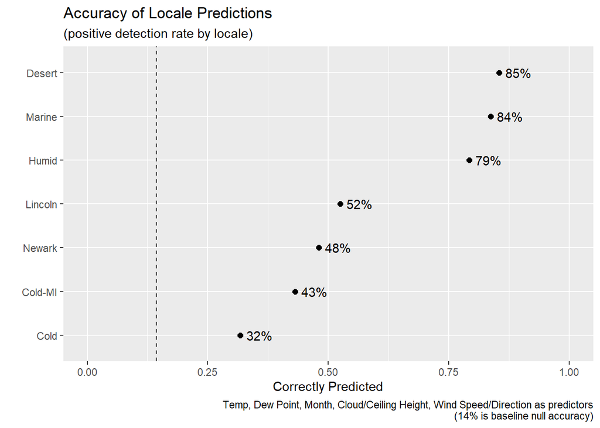

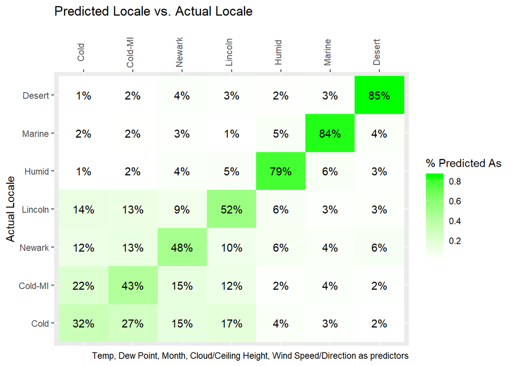

```
## # A tibble: 49 x 5
##    locale  predicted correct     n    pct
##    <fct>   <fct>     <lgl>   <int>  <dbl>
##  1 Cold    Cold      TRUE     2510 0.318
##  2 Cold    Cold-MI   FALSE    2123 0.269
##  3 Cold    Desert    FALSE     150 0.0190
##  4 Cold    Humid     FALSE     322 0.0407
##  5 Cold    Lincoln   FALSE    1351 0.171
##  6 Cold    Marine    FALSE     239 0.0302
##  7 Cold    Newark    FALSE    1210 0.153
##  8 Cold-MI Cold      FALSE    1678 0.216
##  9 Cold-MI Cold-MI   TRUE     3354 0.431
## 10 Cold-MI Desert    FALSE     175 0.0225
## # ... with 39 more rows
```

```r
evalPredictions(rf_types_2016_small_TDmcw,
                plotCaption = "Temp, Dew Point, Month, Cloud/Ceiling Height, Wind Speed/Direction",
                keyVar="locType"
                )
```

As expected, predictions are less accurate with a smaller training dataset. Overall acuuracy falls from ~70% to ~60% with the much smaller training data volumes. This suggests the model is continuing to learn from the data, and may benefit from an expanded sample.

Next, the model is adapted to include the hour (as an integer, which may need to be rethought, though this will generally capture whether it is daytime or nighttime even without factoring) and the sea-level pressure variable:

```r
# Run random forest for all 2016 locale types - add hour and modSLP, limit mtry to 4
rf_types_2016_TDmcwha <- rfMultiLocale(subData,
                                       vrbls=c("TempF", "DewF",
                                               "month", "hr",
                                               "minHeight", "ceilingHeight",
                                               "WindSpeed", "predomDir",
                                               "modSLP"
                                               ),
                                       locs=NULL,
                                       locVar="locType",
                                       pred="locType",
                                       ntree=50,
                                       seed=2006211423,
                                       mtry=4
                                       )
```

```
##
## Running for locations:
## [1] "Cold"    "Cold-MI" "Desert"  "Humid"   "Lincoln" "Marine"  "Newark"
```

The evaluation process can again be run:

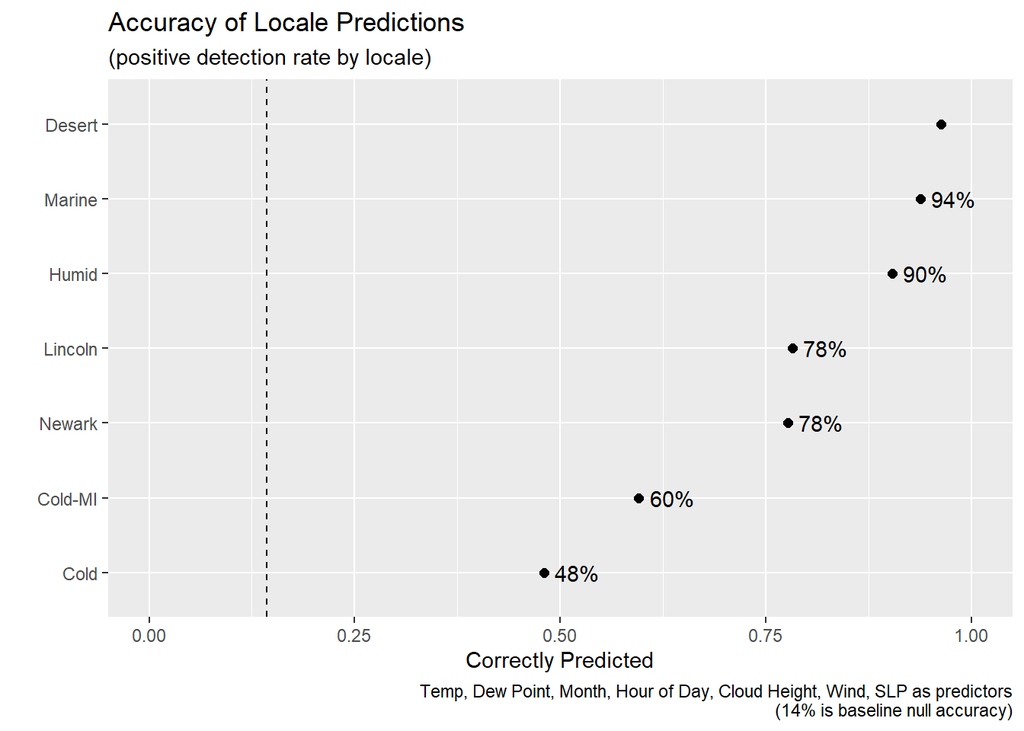

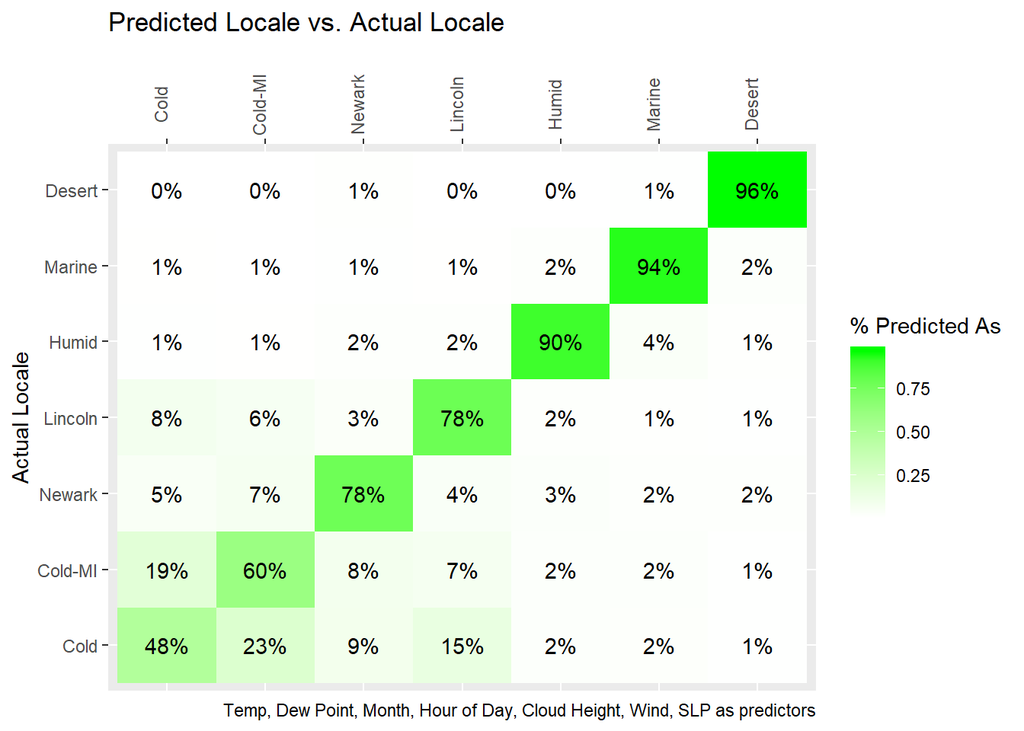

```
## # A tibble: 49 x 5
##    locale  predicted correct     n     pct
##    <fct>   <fct>     <lgl>   <int>   <dbl>
##  1 Cold    Cold      TRUE     1265 0.480
##  2 Cold    Cold-MI   FALSE     615 0.233
##  3 Cold    Desert    FALSE      18 0.00683
##  4 Cold    Humid     FALSE      59 0.0224
##  5 Cold    Lincoln   FALSE     393 0.149
##  6 Cold    Marine    FALSE      53 0.0201
##  7 Cold    Newark    FALSE     233 0.0884
##  8 Cold-MI Cold      FALSE     496 0.194
##  9 Cold-MI Cold-MI   TRUE     1521 0.596
## 10 Cold-MI Desert    FALSE      22 0.00861
## # ... with 39 more rows
```

```r
evalPredictions(rf_types_2016_TDmcwha,
                plotCaption = "Temp, Dew Point, Month, Hour of Day, Cloud Height, Wind, SLP",
                keyVar="locType"
                )
```

Accuracy increases to 75%. In particular, the model is better able to distinguish Lincoln and Newark from the remaining locations, which has a follow-on effect of improving cold weather classifications.

Exploration is then run on distinguishing two locales from each other, to see the implications of parameters like data volume (controlled through testSize) and the number of trees.

Comparisons will be run as follows:

- Desert vs. Humid (should be easiest to pull apart)
- Cold vs. Cold-MI (should be hardest to pull apart)

```r
ntrees <- c(10, 25, 50, 100, 250, 500)
testSizes <- c(0.9, 0.7, 0.3)

desertHumid <- vector("list", length(ntrees) * length(testSizes))
n <- 1

for (ntree in ntrees) {
    for (testSize in testSizes) {

        desertHumid[[n]] <- rfTwoLocales(subData,
                                         loc1="Desert",
                                         loc2="Humid",
                                         locVar="locType",
                                         vrbls=c("TempF", "DewF", "month", "hr",
                                                 "minHeight", "ceilingHeight",
                                                 "WindSpeed", "predomDir", "modSLP"
                                                 ),
                                         pred="locType",
                                         seed=2006211432,
                                         ntree=ntree,
                                         mtry=4,
                                         testSize=testSize
                                         )
        desertHumid[[n]]$ntree <- ntree
        desertHumid[[n]]$testSize <- testSize

        n <- n+1

    }
}
```

An assessment of accuracy can then be performed:

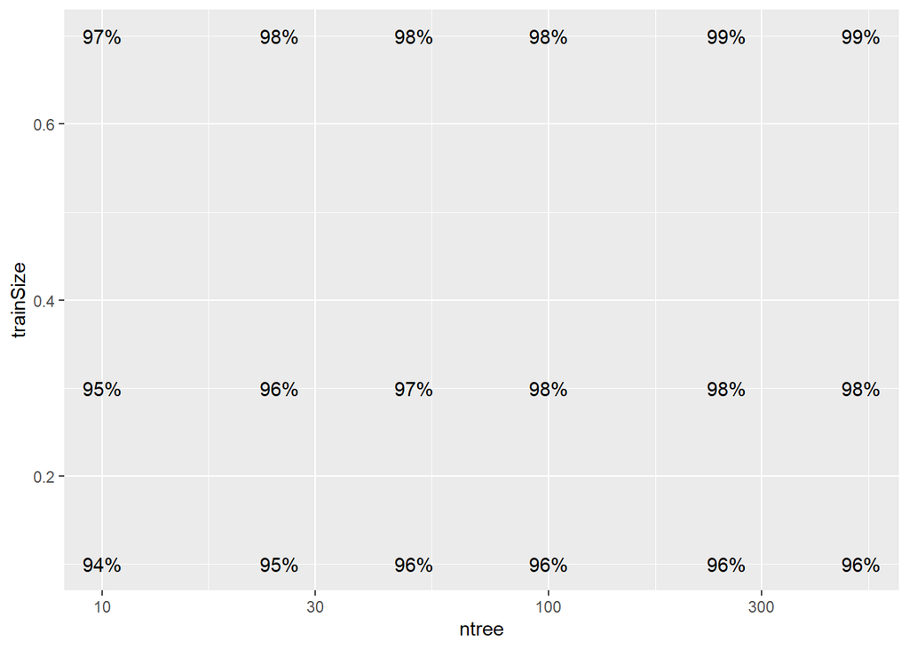

```r
df <- sapply(desertHumid,
             FUN=function(x) { c(x[["errorRate"]]["OOB"], ntree=x$ntree, testSize=x$testSize) }
             ) %>%
    t() %>%
    tibble::as_tibble()

df %>%
    mutate(accuracy=1-OOB, trainSize=1-testSize) %>%
    ggplot(aes(x=ntree, y=trainSize)) +
    geom_text(aes(label=paste0(round(100*accuracy), "%"))) +
    scale_x_log10()
```

As expected, accuracy is very high for distinguishing Desert and Humid climates, even with small data volumes (training size 10% of the data) and a small number of trees.

The approach is then run for the cold weather cities:

```r
ntrees <- c(10, 25, 50, 100, 250, 500)
testSizes <- c(0.9, 0.7, 0.3)

coldColdMI <- vector("list", length(ntrees) * length(testSizes))
n <- 1

for (ntree in ntrees) {
    for (testSize in testSizes) {

        coldColdMI[[n]] <- rfTwoLocales(subData,
                                        loc1="Cold",
                                        loc2="Cold-MI",
                                        locVar="locType",
                                        vrbls=c("TempF", "DewF", "month", "hr",
                                                "minHeight", "ceilingHeight",
                                                "WindSpeed", "predomDir", "modSLP"
                                                ),
                                        pred="locType",
                                        seed=2006211501,
                                        ntree=ntree,
                                        mtry=4,
                                        testSize=testSize
                                        )
        coldColdMI[[n]]$ntree <- ntree
        coldColdMI[[n]]$testSize <- testSize

        n <- n+1

    }
}
```

An assessment of accuracy can then be performed:

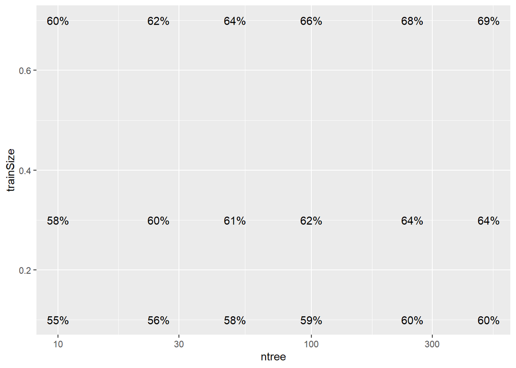

```r
dfColdColdMI <- sapply(coldColdMI,
                       FUN=function(x) { c(x[["errorRate"]]["OOB"], ntree=x$ntree, testSize=x$testSize) }
                       ) %>%
    t() %>%
    tibble::as_tibble()

dfColdColdMI %>%
    mutate(accuracy=1-OOB, trainSize=1-testSize) %>%
    ggplot(aes(x=ntree, y=trainSize)) +
    geom_text(aes(label=paste0(round(100*accuracy), "%"))) +
    scale_x_log10()
```

Data from years other than 2016 can be fed in to the model, with predictions made to see whether the model is learning general differences in climate or specific features about 2016.

Data that were not included in the modeling can be predicted, with the results assessed:

- 2016 data that was not chosen for modeling - serves as an additional test frame
- 2015 and 2017 data - can show the extent to which the model is learning general climate differences as opposed to specific 2016 weather features

Example code includes:

```r
nonUsedData <- modData %>%
    anti_join(select(subData, source, dtime))
nonUsedData %>%
    mutate(localeName=str_replace(locale, pattern=" .{1}\\d{4}.*", replacement="")) %>%
    count(localeName, year) %>%
    pivot_wider(localeName, names_from="year", values_from="n")
```

```
## # A tibble: 15 x 4
##    localeName        `2015` `2016` `2017`
##    <chr>              <int>  <int>  <int>
##  1 Chicago, IL         8728   7285   8740
##  2 Detroit, MI           NA   5912     NA
##  3 Grand Rapids, MI      NA   5811     NA
##  4 Green Bay, WI         NA   7316     NA
##  5 Houston, TX           NA   4407     NA
##  6 Indianapolis, IN      NA   7307     NA
##  7 Las Vegas, NV       8727      8   8664
##  8 Lincoln, NE           NA      3     NA
##  9 Madison, WI           NA   7298     NA
## 10 Milwaukee, WI         NA   7257     NA
## 11 Minneapolis, MN       NA   7296     NA
## 12 New Orleans, LA     8727   4366   8723
## 13 Newark, NJ            NA     11     NA
## 14 San Diego, CA       8737     NA   8744
## 15 Traverse City, MI     NA   5815     NA
```

A function is written to make predictions and plot the results:

```r
# Function to predict model on to df, then plot the outcomes
helperPredictPlot <- function(model,
                              df,
                              vrbls=NULL,
                              origVar="locale",
                              limitObs=500,
                              predOrder=NULL,
                              locMapper=NULL
                              ) {

    # FUNCTION ARGUMENTS:
    # model: a trained model
    # df: a data frame or tibble for the model to be predicted on to
    # vrbls: the variables needed by model (records with NA will be deleted)
    # origVar: the original (truth) variable from df
    # limitObs: the minimum number of observations for a locale to be plotted
    # predOrder: ordering of factor variable "predicted" (NULL means leave as-is)
    # locMapper: mapping file for locations (will order locale to match predicted if not NULL)

    # Get variable names if NULL, assuming random forest
    if (is.null(vrbls)) {
        vrbls <- model$importance %>% rownames()
    }

    # Filter df to have only complete cases for vrbls
    dfPred <- df %>%
        filter_at(vars(all_of(vrbls)), all_vars(!is.na(.)))

    # Make predictions
    dfPred <- dfPred %>%
        mutate(predicted=predict(model, newdata=select_at(dfPred, vars(all_of(vrbls)))))

    # Summarize predictions
    dfAccuracy <- dfPred %>%
        group_by_at(vars(all_of(c(origVar, "predicted")))) %>%
        summarize(n=n()) %>%
        mutate(pct=n/sum(n)) %>%
        ungroup()

    # Filter dfAccuracy to only origVar with count of at least limitObs
    hasEnough <- dfAccuracy %>%
        group_by_at(vars(all_of(origVar))) %>%
        summarize(n=sum(n)) %>%
        filter(n > limitObs) %>%
        pull(origVar)

    # Create the proper order for the factor variable 'predicted' if requested
    if (!is.null(predOrder)) {
        dfAccuracy <- dfAccuracy %>%
            mutate(predicted=factor(predicted, levels=predOrder))
    }

    # Create the base locale mapping
    locales <- dfAccuracy %>%
        pull(origVar) %>%
        unique()

    # Modify the locale mapping if a mapper is provided
    if (!is.null(locMapper) & !is.null(predOrder)) {
        localeStrip <- str_replace(locales, pattern=" .\\d{4}.", replacement="")
        locales <- locales[order(match(locMapper[localeStrip], predOrder))]
    }

    # Create plot for which locales are classified as each other
    p1 <- dfAccuracy %>%
        filter_at(vars(all_of(origVar)), all_vars(. %in% hasEnough)) %>%
        mutate(locale=factor(get(origVar), levels=locales)) %>%
        ggplot(aes(y=locale, x=predicted)) +
        geom_tile(aes(fill=pct)) +
        geom_text(aes(label=paste0(round(100*pct), "%"))) +
        scale_fill_continuous("% Predicted As", low="white", high="green") +
        scale_x_discrete(position="top") +
        theme(axis.text.x=element_text(angle=90)) +
        labs(x="",
             y="Actual Locale",
             title="Predicted Locale vs. Actual Locale"
             )
    print(p1)

    # Return the predictions summary
    dfAccuracy

}
```

The function can then be applied to the 2016 data:

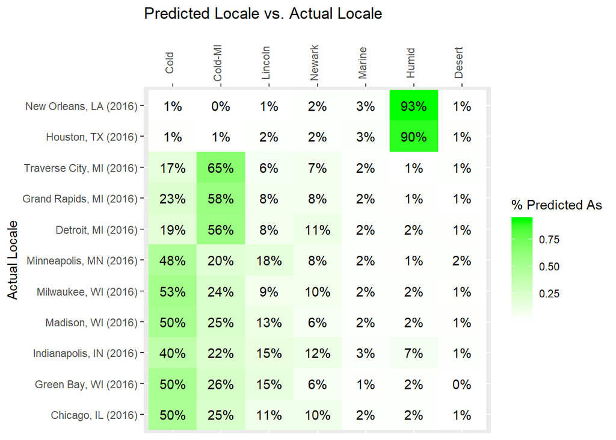

```
## # A tibble: 83 x 4
##    locale             predicted     n     pct
##    <chr>              <fct>     <int>   <dbl>
##  1 Chicago, IL (2016) Cold       3608 0.496
##  2 Chicago, IL (2016) Cold-MI    1792 0.246
##  3 Chicago, IL (2016) Desert       60 0.00825
##  4 Chicago, IL (2016) Humid       165 0.0227
##  5 Chicago, IL (2016) Lincoln     766 0.105
##  6 Chicago, IL (2016) Marine      157 0.0216
##  7 Chicago, IL (2016) Newark      728 0.100
##  8 Detroit, MI (2016) Cold       1111 0.189
##  9 Detroit, MI (2016) Cold-MI    3290 0.560
## 10 Detroit, MI (2016) Desert       66 0.0112
## # ... with 73 more rows
```

```r
# Modify the file for mapping locale to type
localeMapper <- locale2016Mapper
names(localeMapper) <- str_replace(names(localeMapper), pattern=" .\\d{4}.", replacement="")

# Predictions on 2016 data
helperPredictPlot(rf_types_2016_TDmcwha$rfModel,
                  df=filter(nonUsedData, year==2016),
                  predOrder=c("Cold", "Cold-MI", "Lincoln", "Newark", "Marine", "Humid", "Desert"),
                  locMapper=localeMapper
                  )
```

The predictions seem in-line with the test dataset conclusions, as would be expected given that the “unused” 2016 data are randomly sampled and should be no different than that “test” 2016 dataset.

The function can then be applied to the 2015 and 2017 data:

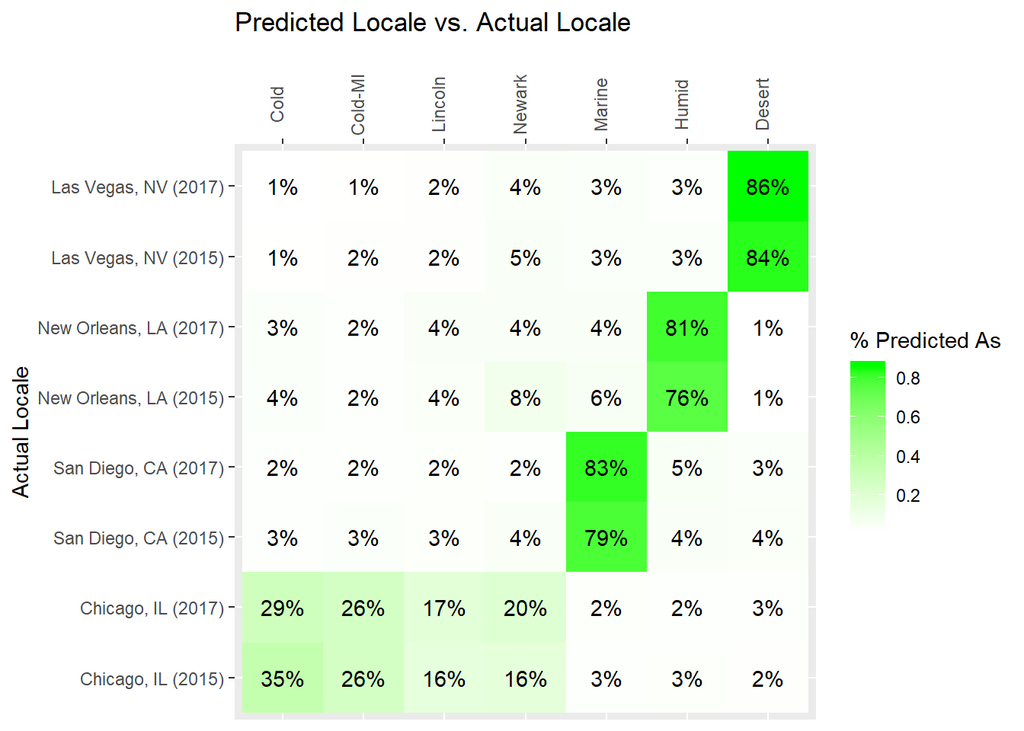

```
## # A tibble: 56 x 4
##    locale             predicted     n    pct
##    <chr>              <fct>     <int>  <dbl>
##  1 Chicago, IL (2015) Cold       3043 0.349
##  2 Chicago, IL (2015) Cold-MI    2269 0.260
##  3 Chicago, IL (2015) Desert      137 0.0157
##  4 Chicago, IL (2015) Humid       257 0.0295
##  5 Chicago, IL (2015) Lincoln    1373 0.157
##  6 Chicago, IL (2015) Marine      223 0.0256
##  7 Chicago, IL (2015) Newark     1418 0.163
##  8 Chicago, IL (2017) Cold       2537 0.291
##  9 Chicago, IL (2017) Cold-MI    2299 0.263
## 10 Chicago, IL (2017) Desert      227 0.0260
## # ... with 46 more rows
```

```r
# Predictions on 2015/2017 data
helperPredictPlot(rf_types_2016_TDmcwha$rfModel,
                  df=filter(nonUsedData, year!=2016),
                  predOrder=c("Cold", "Cold-MI", "Lincoln", "Newark", "Marine", "Humid", "Desert"),
                  locMapper=localeMapper
                  )
```

Model performance on 2015 and 2017 data is not as strong, with roughly a 10%-20% loss of accuracy. Predictions are still much better than null accuracy, and the model (mostly) continues to separate the three well-differentiated types (Desert, Humid, Marine).